# MALCOM: Machine Learning for Communication Systems

## Lab Assignment #2

### Arnaud Barral

In the two following code cells below is the completed code from the shared .py file (we reorganized it in a way that was more convenient for us) :

### 1) Imports

```python
# importing libraries

import tensorflow as tf
from tensorflow import keras
from tensorflow.keras.models import Sequential

from tensorflow.keras.layers import Input, Dense, GaussianNoise, Lambda, BatchNormalization
from tensorflow.keras.models import Model
#from keras.layers import ActivityRegularization
#from keras.layers.normalization import BatchNormalization
from tensorflow.keras.optimizers import Adam,SGD

from tensorflow.keras import backend as K
import numpy as np
import random as rd
import matplotlib.pyplot as plt

print("loading complete")
```

```
loading complete
```

### 2) Model definition , compilation, & tests

```python
def testModel(k= 2, n=2, fixedEnergyConstraint = True, questionD = False, nonlinearD1 = False, nonlinearD2 = False, questionE = False,increaseNbrLayer = False):

    # Initialization - Autoencoder (n,k)
    # M: number of messages to encode
    # k = log2(M)
    # n real-value signals (otherwise. for complex-valued signals, 2*n real numbers)
    k = k
    n = n
    M = 2**k
    R = k/n

    print(" ********* Testing autoencoder architecture ********* ")
    print(" ")
    print('M:',M,'\t','k:',k,'\t','n:',n)
    print(" ")

    # Channel parameters
    Eb_No_dB = 7
    noise = 1/(10**(Eb_No_dB/10))
    noise_sigma = np.sqrt(noise)
    beta = 1/(2*R*(10**(Eb_No_dB/10)))
    beta_sqrt = np.sqrt(beta)


    # Creating a training set and test set
    eye_matrix = np.eye(M)
    x_train = np.tile(eye_matrix, (1000, 1))
    x_test = np.tile(eye_matrix, (100, 1))
    rd.shuffle(x_train)
    rd.shuffle(x_test)


    # Printing the shape of x_train and x_test
    print(x_train.shape)
    print(x_test.shape)


    #Bit Error Rate
    def BER(y_true, y_pred):
        return K.mean(K.not_equal(y_true, K.round(y_pred)), axis=-1)


    # Autoencoder definition/construction

    # Take the input and convert it to Keras tensors
    input_signal = Input(shape=(M,))
    encoded_input = Input(shape=(n,))

    #Transmitter Neural Network (encoder)


    ######## YOUR CODE STARTS HERE #######
    #### Create two dense layers, with input 'input_signal' and output 'encoded' ####
    ### The first layer has activation ReLU and the second linear
    if  questionE:   #We are at any other question than question D
        print("--- Question e) ---")
        if increaseNbrLayer:
            layer_T1 = Dense(M, input_shape=(M,), activation = K.relu)(input_signal)
            layer_T2 = Dense(M,  activation = K.relu)(layer_T1)
            encoded = Dense(n, activation = K.relu) (layer_T2 )
        else:
            encoded = Dense(n, input_shape=(M,))(input_signal)

    elif questionD:
        print("--- Question d) ---")
        if nonlinearD1: #We add some nonlinearity
            print("Test with more nonlinearity -input")
            layer_T = Dense(M, input_shape=(M,), activation = K.relu)(input_signal)
            encoded = Dense(n, activation = K.relu) (layer_T )
        else: #we test the linear dense layers
            print("Test with no nonlinearity -input")
            layer_T = Dense(M, input_shape=(M,))(input_signal)
            encoded = Dense(n) (layer_T )
    else:
        layer_T = Dense(M, input_shape=(M,), activation = K.relu)(input_signal)
        encoded = Dense(n) (layer_T )
    ######## END OF YOUR CODE      #######



    # If you want to use regularizers or perform batch normalization, uncomment the below
    #encoded = ActivityRegularization(l2=0.02)(encoded)
    #encoded = BatchNormalization()(encoded)

    # Signal constraints
    if fixedEnergyConstraint:
        print("Fixed energy constraint")
        encoded = Lambda(lambda x: np.sqrt(n) * K.l2_normalize(x, axis=1))(encoded) #energy constraint
    ######## YOUR CODE STARTS HERE #######
    #### The above command implement a fixed energy constraint. For the question on implementing an average power constraint ####
    #### Comment the above line and write your own command for the power constraint ####
    elif not fixedEnergyConstraint:
        print("Average energy constraint")
        ## Not sure about this
        #encoded = BatchNormalization(momentum = 0)(encoded)
        def average_energy_constraint(x):
            return tf.cond(tf.norm(x, ord=2) > 1, lambda: K.l2_normalize(x, axis=1), lambda: x)
        encoded = Lambda(average_energy_constraint)(encoded)
    ######## END OF YOUR CODE      #######






    # Channel Layer
    encoded_noise = GaussianNoise(beta_sqrt)(encoded)

    # Receiver Neural Network (decoder)

    ######## YOUR CODE STARTS HERE #######
    #### Create two dense layers, with input 'encoded_noise' and output 'decoded' ####
    ### The first layer has activation ReLU and the second softmax
    if questionE:   #We are at any other question than question D
        if increaseNbrLayer: #keep the same
            layer_R = Dense(M, activation = K.relu)(encoded_noise)
            decoded = Dense(M, activation = K.softmax)(layer_R)

        else:
            decoded = Dense(M, activation = K.softmax)(encoded_noise)


    elif questionD:
        if nonlinearD2: #We add some nonlinearity with the softmax
            print("Test with less nonlinearity in question d -output")
            layer_R = Dense(M)(encoded_noise)
            decoded = Dense(M, activation = K.softmax)(layer_R)
        else: #we test the linear dense layers
            print("Test with no nonlinearity in question d -output")
            layer_R = Dense(M)(encoded_noise)
            decoded = Dense(M)(layer_R)
    else:
        layer_R = Dense(M, activation = K.relu)(encoded_noise)
        decoded = Dense(M, activation = K.softmax)(layer_R)


    ######## END OF YOUR CODE      #######


    # We create the autoencoder with input_signal as the input and output being the final decoder layer
    autoencoder = Model(inputs=input_signal, outputs=decoded)


    # We extract the encoder that takes the input_signal as the input and the output of the encoder is the encoded signal
    encoder = Model(inputs=input_signal, outputs=encoded)


    # To show the structure of the deep autoencodder (layers, trainable parameters,...)
    autoencoder.summary()



    # We compile the autoencoder model with Adam optimizer and categorical cross entropy as loss function

    # To change the learning rate of Adam optimizer and/or SGD, you can use the following commmands
    #adam=Adam(lr=0.001)
    #sgd=SGD(lr=0.02)

    autoencoder.compile(optimizer='adam', loss='categorical_crossentropy', metrics=['binary_accuracy',BER])

    # Training of the autoencoder with 200 epochs and batch size of 32 (default value)
    hist = autoencoder.fit(x_train, x_train, epochs=10, batch_size=32,validation_data=(x_test, x_test))



    # Predicting the test set using the encoder to view the encoded signal
    encoded_signal = encoder.predict(x_test)
    # Predicting the test set using the autoencoder to view (obtain) the encoded (reconstructed) signal
    decoded_signal = autoencoder.predict(x_test)


    import matplotlib.pyplot as plt
    # Plotting the constellation diagram
    encoded_planisphere = encoder.predict(eye_matrix)
    plt.figure()
    plt.title('Constellation')
    plt.xlim(-2, 2)
    plt.ylim(-2, 2)
    plt.plot(encoded_planisphere[:,0], encoded_planisphere[:,1], 'r.')
    plt.grid(True)
    plt.xlabel('I axis')
    plt.ylabel('Q axis')

    # Plotting the model loss vs. epochs
    plt.figure()
    plt.plot(hist.history['loss'])
    plt.title('Model loss')
    plt.ylabel('Loss')
    plt.xlabel('Epoch')


    # making decoder from full autoencoder
    deco = autoencoder.layers[-2](encoded_input)
    deco = autoencoder.layers[-1](deco)
    decoder = Model(encoded_input, deco)


    # Calculating BER from -2dB to 10dB Eb/No

    # Generating data of size N
    N=100000
    test_label = np.random.randint(M,size=N)

    # Creating one hot encoded vectors
    test_data=[]
    for i in test_label:
        temp=np.zeros(M)
        temp[i]=1
        test_data.append(temp)
    # Checking data shape
    test_data=np.array(test_data)

    EbNodB_range = list(np.arange(-2.0,10+1,1))
    ber = [None]*len(EbNodB_range)
    for n_i in range(0,len(EbNodB_range)):
        EbNo=10.0**(EbNodB_range[n_i]/10.0)
        noise_std = np.sqrt(1/(2*R*EbNo))
        noise_mean = 0
        no_errors = 0
        nn = N
        noise = noise_std*np.random.randn(nn,n)
        encoded_signal = encoder.predict(test_data)
        final_signal = encoded_signal+noise
        pred_final_signal =  decoder.predict(final_signal)
        pred_output = np.argmax(pred_final_signal,axis=1)
        no_errors = (pred_output != test_label)
        no_errors =  no_errors.astype(int).sum()
        ber[n_i] = no_errors / nn
        print ('Eb/No:',EbNodB_range[n_i],'BLER:',ber[n_i])


    # ploting BER curve

    plt.figure()
    plt.plot(EbNodB_range, ber, 'bo',label='Autoencoder(2,2)')
    plt.yscale('log')
    plt.xlabel('Eb/No [dB]')
    plt.ylabel('Block error rate')
    plt.grid(True)
    plt.legend(loc='upper right',ncol = 1)
    plt.ylim(10**-5,1)
    plt.xlim(-2,10)
    plt.show()
```

### Question a) & b)

Defining the model (with fixed power constraint), and plotting graphs

#### n=2, k=4

```
 ********* Testing autoencoder architecture *********

M: 16 	 k: 4 	 n: 2

(16000, 16)
(1600, 16)
Fixed energy constraint
Model: "model_90"
_________________________________________________________________
Layer (type)                 Output Shape              Param #
=================================================================
input_101 (InputLayer)       [(None, 16)]              0
_________________________________________________________________
dense_160 (Dense)            (None, 16)                272
_________________________________________________________________
dense_161 (Dense)            (None, 2)                 34
_________________________________________________________________
lambda_49 (Lambda)           (None, 2)                 0
_________________________________________________________________
gaussian_noise_31 (GaussianN (None, 2)                 0
_________________________________________________________________
dense_162 (Dense)            (None, 16)                48
_________________________________________________________________
dense_163 (Dense)            (None, 16)                272
=================================================================
Total params: 626
Trainable params: 626
Non-trainable params: 0
_________________________________________________________________
Train on 16000 samples, validate on 1600 samples
Eb/No: -2.0 BLER: 0.66167
Eb/No: -1.0 BLER: 0.62378
Eb/No: 0.0 BLER: 0.58486
Eb/No: 1.0 BLER: 0.53799
Eb/No: 2.0 BLER: 0.48824
Eb/No: 3.0 BLER: 0.44003
Eb/No: 4.0 BLER: 0.38372
Eb/No: 5.0 BLER: 0.33301
Eb/No: 6.0 BLER: 0.27891
Eb/No: 7.0 BLER: 0.22459
Eb/No: 8.0 BLER: 0.17404
Eb/No: 9.0 BLER: 0.13193
Eb/No: 10.0 BLER: 0.09358
```

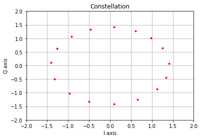

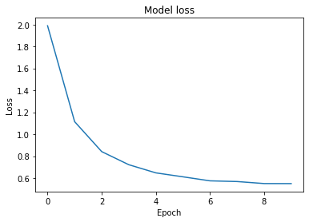

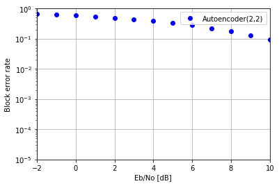

```python
testModel(n=2, k=4,  fixedEnergyConstraint=True)
```

#### n=2, k=2

```
 ********* Testing autoencoder architecture *********

M: 4 	 k: 2 	 n: 2

(4000, 4)
(400, 4)
Fixed energy constraint
Model: "model_3"
_________________________________________________________________
Layer (type)                 Output Shape              Param #
=================================================================
input_5 (InputLayer)         [(None, 4)]               0
_________________________________________________________________
dense_6 (Dense)              (None, 4)                 20
_________________________________________________________________
dense_7 (Dense)              (None, 2)                 10
_________________________________________________________________
lambda_2 (Lambda)            (None, 2)                 0
_________________________________________________________________
gaussian_noise_1 (GaussianNo (None, 2)                 0
_________________________________________________________________
dense_8 (Dense)              (None, 4)                 12
_________________________________________________________________
dense_9 (Dense)              (None, 4)                 20
=================================================================
Total params: 62
Trainable params: 62
Non-trainable params: 0
_________________________________________________________________
Train on 4000 samples, validate on 400 samples
Eb/No: -2.0 BLER: 0.25785
Eb/No: -1.0 BLER: 0.21174
Eb/No: 0.0 BLER: 0.1668
Eb/No: 1.0 BLER: 0.12871
Eb/No: 2.0 BLER: 0.0902
Eb/No: 3.0 BLER: 0.06222
Eb/No: 4.0 BLER: 0.03728
Eb/No: 5.0 BLER: 0.02072
Eb/No: 6.0 BLER: 0.01035
Eb/No: 7.0 BLER: 0.00452
Eb/No: 8.0 BLER: 0.00175
Eb/No: 9.0 BLER: 0.00044
Eb/No: 10.0 BLER: 0.00012
```

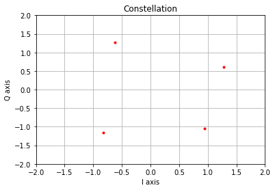

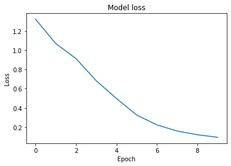

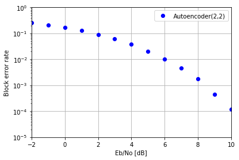

```python
testModel( fixedEnergyConstraint=True)
```

### COMMENTS

##### For n=2, k=4

It is almost like 16-PSK with a very small rotation. The more symbols there are, the harder it is to differentiate between them since there are more symbols closer than before because we are using the same fixed energy constraint. So the model is trying to learn a constellation like 16-PSK, since this one offers the best minimum distance between two symbols.

### Question c)

Same as before, but with average power constraint

```
 ********* Testing autoencoder architecture *********

M: 16 	 k: 4 	 n: 2

(16000, 16)
(1600, 16)
Average energy constraint
Model: "model_63"
_________________________________________________________________
Layer (type)                 Output Shape              Param #
=================================================================
input_83 (InputLayer)        [(None, 16)]              0
_________________________________________________________________
dense_126 (Dense)            (None, 16)                272
_________________________________________________________________
dense_127 (Dense)            (None, 2)                 34
_________________________________________________________________
lambda_40 (Lambda)           (None, 2)                 0
_________________________________________________________________
gaussian_noise_22 (GaussianN (None, 2)                 0
_________________________________________________________________
dense_128 (Dense)            (None, 16)                48
_________________________________________________________________
dense_129 (Dense)            (None, 16)                272
=================================================================
Total params: 626
Trainable params: 626
Non-trainable params: 0
_________________________________________________________________
Train on 16000 samples, validate on 1600 samples
Eb/No: -2.0 BLER: 0.75284
Eb/No: -1.0 BLER: 0.72897
Eb/No: 0.0 BLER: 0.69741
Eb/No: 1.0 BLER: 0.66624
Eb/No: 2.0 BLER: 0.62436
Eb/No: 3.0 BLER: 0.58572
Eb/No: 4.0 BLER: 0.54045
Eb/No: 5.0 BLER: 0.49612
Eb/No: 6.0 BLER: 0.44402
Eb/No: 7.0 BLER: 0.39251
Eb/No: 8.0 BLER: 0.3397
Eb/No: 9.0 BLER: 0.28644
Eb/No: 10.0 BLER: 0.23499
```

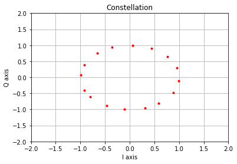

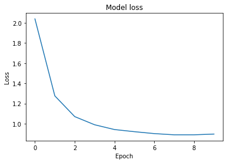

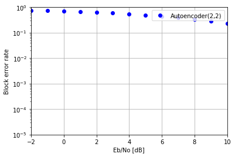

```python
testModel(fixedEnergyConstraint = False, n=2, k=4)  #as we have here fixedEnergyConstraint = False
```

### COMMENTS

It is almost like b) with n=2 and k=4. The block error rate is bigger because the symbols are closer to the origin so closer to each other since we are using an average power constraint.

### Question d)

Same as before, but with different activation functions

```
At first glance, I would think that the linear activation in the second layer is not necessary, and could be more useful by adding some nonlinearity. However, this was a false assumption (as it can be seen from the graphs). I also thought that the softmax output is important and should be kept, as the softmax function is a nice way to get a probability in output. And from the graphs, it also seems that it is better to keep the softmax.
```

```
 ********* Testing autoencoder architecture *********

M: 4 	 k: 2 	 n: 2

(4000, 4)
(400, 4)
--- Question d) ---
Test with no nonlinearity -input
Fixed energy constraint
Test with no nonlinearity in question d -output
Model: "model_72"
_________________________________________________________________
Layer (type)                 Output Shape              Param #
=================================================================
input_89 (InputLayer)        [(None, 4)]               0
_________________________________________________________________
dense_137 (Dense)            (None, 4)                 20
_________________________________________________________________
dense_138 (Dense)            (None, 2)                 10
_________________________________________________________________
lambda_43 (Lambda)           (None, 2)                 0
_________________________________________________________________
gaussian_noise_25 (GaussianN (None, 2)                 0
_________________________________________________________________
dense_139 (Dense)            (None, 4)                 12
_________________________________________________________________
dense_140 (Dense)            (None, 4)                 20
=================================================================
Total params: 62
Trainable params: 62
Non-trainable params: 0
_________________________________________________________________
Train on 4000 samples, validate on 400 samples
Eb/No: -2.0 BLER: 0.7523
Eb/No: -1.0 BLER: 0.74481
Eb/No: 0.0 BLER: 0.73484
Eb/No: 1.0 BLER: 0.72207
Eb/No: 2.0 BLER: 0.71247
Eb/No: 3.0 BLER: 0.70178
Eb/No: 4.0 BLER: 0.69267
Eb/No: 5.0 BLER: 0.68446
Eb/No: 6.0 BLER: 0.67983
Eb/No: 7.0 BLER: 0.67432
Eb/No: 8.0 BLER: 0.67143
Eb/No: 9.0 BLER: 0.67071
Eb/No: 10.0 BLER: 0.67493
```

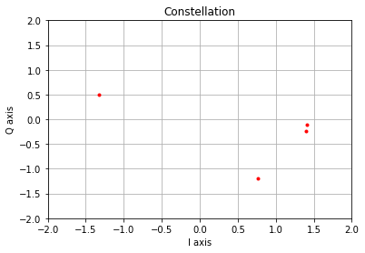

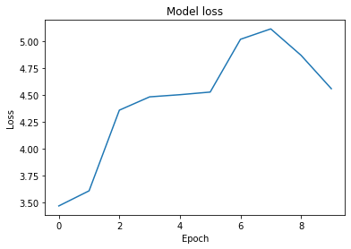

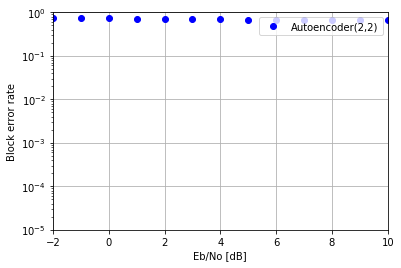

```python
testModel( questionD = True, nonlinearD1 = False, nonlinearD2 = False)
#Every dense layer is linear
```

```
From the graphs above, we can see that if everything is linear, we get terrible results
```

```
 ********* Testing autoencoder architecture *********

M: 4 	 k: 2 	 n: 2

(4000, 4)
(400, 4)
--- Question d) ---
Test with no nonlinearity -input
Fixed energy constraint
Test with less nonlinearity in question d -output
Model: "model_9"
_________________________________________________________________
Layer (type)                 Output Shape              Param #
=================================================================
input_7 (InputLayer)         [(None, 4)]               0
_________________________________________________________________
dense_12 (Dense)             (None, 4)                 20
_________________________________________________________________
dense_13 (Dense)             (None, 2)                 10
_________________________________________________________________
lambda_2 (Lambda)            (None, 2)                 0
_________________________________________________________________
gaussian_noise_3 (GaussianNo (None, 2)                 0
_________________________________________________________________
dense_14 (Dense)             (None, 4)                 12
_________________________________________________________________
dense_15 (Dense)             (None, 4)                 20
=================================================================
Total params: 62
Trainable params: 62
Non-trainable params: 0
_________________________________________________________________
Train on 4000 samples, validate on 400 samples
Eb/No: -2.0 BLER: 0.24681
Eb/No: -1.0 BLER: 0.19675
Eb/No: 0.0 BLER: 0.14924
Eb/No: 1.0 BLER: 0.11041
Eb/No: 2.0 BLER: 0.07464
Eb/No: 3.0 BLER: 0.04654
Eb/No: 4.0 BLER: 0.02599
Eb/No: 5.0 BLER: 0.01229
Eb/No: 6.0 BLER: 0.00514
Eb/No: 7.0 BLER: 0.00175
Eb/No: 8.0 BLER: 0.00045
Eb/No: 9.0 BLER: 7e-05
Eb/No: 10.0 BLER: 0.0
```

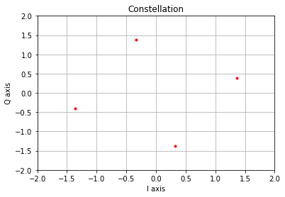

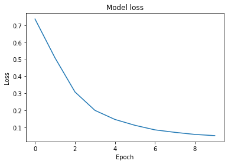

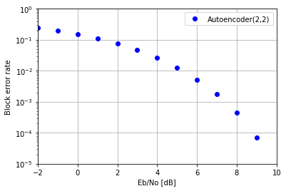

```python
testModel( questionD = True, nonlinearD1 = False, nonlinearD2 = True)
#All dense layers are linear, excepted the last one (the softmax output)
```

```
With only a softmax, the rest being linear, we get some quite decent results.
```

```
 ********* Testing autoencoder architecture *********

M: 4 	 k: 2 	 n: 2

(4000, 4)
(400, 4)
--- Question d) ---
Test with more nonlinearity -input
Fixed energy constraint
Test with no nonlinearity in question d -output
Model: "model_12"
_________________________________________________________________
Layer (type)                 Output Shape              Param #
=================================================================
input_9 (InputLayer)         [(None, 4)]               0
_________________________________________________________________
dense_16 (Dense)             (None, 4)                 20
_________________________________________________________________
dense_17 (Dense)             (None, 2)                 10
_________________________________________________________________
lambda_3 (Lambda)            (None, 2)                 0
_________________________________________________________________
gaussian_noise_4 (GaussianNo (None, 2)                 0
_________________________________________________________________
dense_18 (Dense)             (None, 4)                 12
_________________________________________________________________
dense_19 (Dense)             (None, 4)                 20
=================================================================
Total params: 62
Trainable params: 62
Non-trainable params: 0
_________________________________________________________________
Train on 4000 samples, validate on 400 samples
Eb/No: -2.0 BLER: 0.67325
Eb/No: -1.0 BLER: 0.66519
Eb/No: 0.0 BLER: 0.65966
Eb/No: 1.0 BLER: 0.65352
Eb/No: 2.0 BLER: 0.64866
Eb/No: 3.0 BLER: 0.64644
Eb/No: 4.0 BLER: 0.64392
Eb/No: 5.0 BLER: 0.64134
Eb/No: 6.0 BLER: 0.64214
Eb/No: 7.0 BLER: 0.64112
Eb/No: 8.0 BLER: 0.64203
Eb/No: 9.0 BLER: 0.64349
Eb/No: 10.0 BLER: 0.64484
```

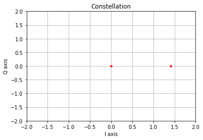

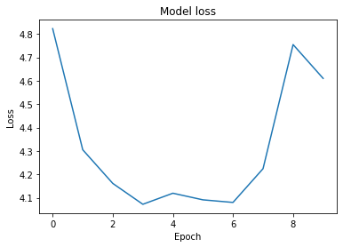

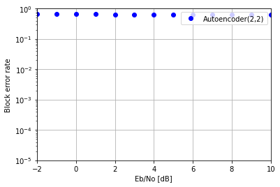

```python
testModel( questionD = True, nonlinearD1 = True, nonlinearD2 = False)
```

```
With non linearities only at the encoding phase, but no softmax, we get terrible results.
```

```
 ********* Testing autoencoder architecture *********

M: 4 	 k: 2 	 n: 2

(4000, 4)
(400, 4)
--- Question d) ---
Test with more nonlinearity -input
Fixed energy constraint
Test with less nonlinearity in question d -output
Model: "model_15"
_________________________________________________________________
Layer (type)                 Output Shape              Param #
=================================================================
input_11 (InputLayer)        [(None, 4)]               0
_________________________________________________________________
dense_20 (Dense)             (None, 4)                 20
_________________________________________________________________
dense_21 (Dense)             (None, 2)                 10
_________________________________________________________________
lambda_4 (Lambda)            (None, 2)                 0
_________________________________________________________________
gaussian_noise_5 (GaussianNo (None, 2)                 0
_________________________________________________________________
dense_22 (Dense)             (None, 4)                 12
_________________________________________________________________
dense_23 (Dense)             (None, 4)                 20
=================================================================
Total params: 62
Trainable params: 62
Non-trainable params: 0
_________________________________________________________________
Train on 4000 samples, validate on 400 samples
Eb/No: -2.0 BLER: 0.60785
Eb/No: -1.0 BLER: 0.59413
Eb/No: 0.0 BLER: 0.58138
Eb/No: 1.0 BLER: 0.56755
Eb/No: 2.0 BLER: 0.55376
Eb/No: 3.0 BLER: 0.54061
Eb/No: 4.0 BLER: 0.5304
Eb/No: 5.0 BLER: 0.51869
Eb/No: 6.0 BLER: 0.51492
Eb/No: 7.0 BLER: 0.51026
Eb/No: 8.0 BLER: 0.50403
Eb/No: 9.0 BLER: 0.50099
Eb/No: 10.0 BLER: 0.50294
```

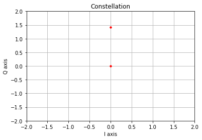

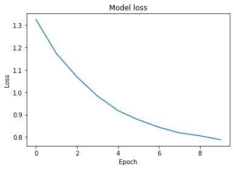

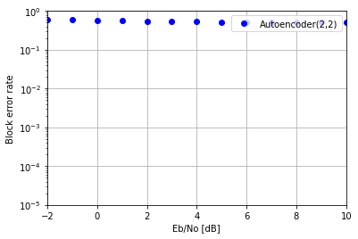

```python
testModel( questionD = True, nonlinearD1 = True, nonlinearD2 = True)
```

```
With only non linear activations, we get some quite bad results.
```

### Comments

Results are very different than what was expected. Keeping the softmax output seems mandatory (to get a probability as an output). However, surprisingly, it seems that keeping some linear layers (with linear activation) is helpfull. Even if we expected at first glance non linear functions such as relu to help achieving better results, we can think of a few arguments that could explain why linear activations can help achieve better results. To begin with, the application is a communication system, where coding/modulation processes are often linear. Therefore, if we have a linear coding process, the decoding process could also be linear (we could find some kind of symetry between the two processes). So, it means that if we choose linear activations in the encoder part our autoencoder, it might be better to also choose linear activations for the decoder part.

Also, in our specific case, we want the output to be similar to the input. Therefore, a linear activation could be convenient, much more than some other types of activations, as it will produce outputs that are similar to the inputs.

Also, linear layers are also good in our setting, because of the simplicity of our model/channels/noise model. With other types of models, more complex, with multiplicative noise for instance, the linear layers might not be that great, and ReLU might be a better option

### Question e)

Testing the influence of the number of layers on the model.

```
 ********* Testing autoencoder architecture *********

M: 4 	 k: 2 	 n: 2

(4000, 4)
(400, 4)
--- Question e) ---
Fixed energy constraint
Model: "model_75"
_________________________________________________________________
Layer (type)                 Output Shape              Param #
=================================================================
input_91 (InputLayer)        [(None, 4)]               0
_________________________________________________________________
dense_141 (Dense)            (None, 2)                 10
_________________________________________________________________
lambda_44 (Lambda)           (None, 2)                 0
_________________________________________________________________
gaussian_noise_26 (GaussianN (None, 2)                 0
_________________________________________________________________
dense_142 (Dense)            (None, 4)                 12
=================================================================
Total params: 22
Trainable params: 22
Non-trainable params: 0
_________________________________________________________________
Train on 4000 samples, validate on 400 samples
Eb/No: -2.0 BLER: 0.24176
Eb/No: -1.0 BLER: 0.1963
Eb/No: 0.0 BLER: 0.15135
Eb/No: 1.0 BLER: 0.11117
Eb/No: 2.0 BLER: 0.07306
Eb/No: 3.0 BLER: 0.04601
Eb/No: 4.0 BLER: 0.02492
Eb/No: 5.0 BLER: 0.01234
Eb/No: 6.0 BLER: 0.00501
Eb/No: 7.0 BLER: 0.00141
Eb/No: 8.0 BLER: 0.00032
Eb/No: 9.0 BLER: 7e-05
Eb/No: 10.0 BLER: 0.0
```

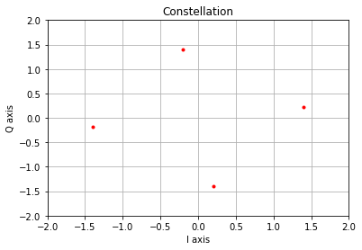

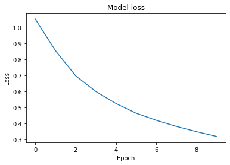

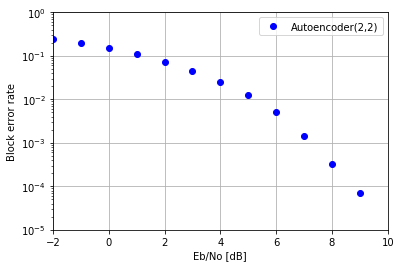

```python
testModel(questionE = True,increaseNbrLayer = False)
```

```
 ********* Testing autoencoder architecture *********

M: 4 	 k: 2 	 n: 2

(4000, 4)
(400, 4)
--- Question e) ---
Fixed energy constraint
Model: "model_78"
_________________________________________________________________
Layer (type)                 Output Shape              Param #
=================================================================
input_93 (InputLayer)        [(None, 4)]               0
_________________________________________________________________
dense_143 (Dense)            (None, 4)                 20
_________________________________________________________________
dense_144 (Dense)            (None, 4)                 20
_________________________________________________________________
dense_145 (Dense)            (None, 2)                 10
_________________________________________________________________
lambda_45 (Lambda)           (None, 2)                 0
_________________________________________________________________
gaussian_noise_27 (GaussianN (None, 2)                 0
_________________________________________________________________
dense_146 (Dense)            (None, 4)                 12
_________________________________________________________________
dense_147 (Dense)            (None, 4)                 20
=================================================================
Total params: 82
Trainable params: 82
Non-trainable params: 0
_________________________________________________________________
Train on 4000 samples, validate on 400 samples
Eb/No: -2.0 BLER: 0.75086
Eb/No: -1.0 BLER: 0.74968
Eb/No: 0.0 BLER: 0.74992
Eb/No: 1.0 BLER: 0.74964
Eb/No: 2.0 BLER: 0.75069
Eb/No: 3.0 BLER: 0.75243
Eb/No: 4.0 BLER: 0.74945
Eb/No: 5.0 BLER: 0.74862
Eb/No: 6.0 BLER: 0.74865
Eb/No: 7.0 BLER: 0.74758
Eb/No: 8.0 BLER: 0.74973
Eb/No: 9.0 BLER: 0.74978
Eb/No: 10.0 BLER: 0.74979
```

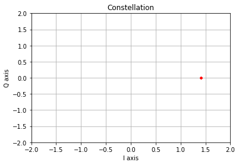

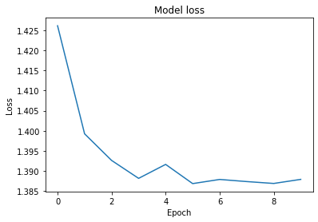

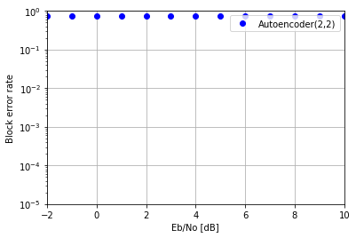

```python
testModel(questionE = True,increaseNbrLayer = True)
```

```
    We can see from the graphs above that decreasing the number of layers does not change the output
    (and can even  improve it), whereas adding layers seems to make the model less efficient...
```

### Comments

By increasing the number of layers it may cause overfitting? But it might also be the non linearity of the additionnal layers that have hurt the model's performance...

### Question f)

Testing the influence of **n** and **k** on the model.

```
 ********* Testing autoencoder architecture *********

M: 4 	 k: 2 	 n: 2

(4000, 4)
(400, 4)
Fixed energy constraint
Model: "model_81"
_________________________________________________________________
Layer (type)                 Output Shape              Param #
=================================================================
input_95 (InputLayer)        [(None, 4)]               0
_________________________________________________________________
dense_148 (Dense)            (None, 4)                 20
_________________________________________________________________
dense_149 (Dense)            (None, 2)                 10
_________________________________________________________________
lambda_46 (Lambda)           (None, 2)                 0
_________________________________________________________________
gaussian_noise_28 (GaussianN (None, 2)                 0
_________________________________________________________________
dense_150 (Dense)            (None, 4)                 12
_________________________________________________________________
dense_151 (Dense)            (None, 4)                 20
=================================================================
Total params: 62
Trainable params: 62
Non-trainable params: 0
_________________________________________________________________
Train on 4000 samples, validate on 400 samples
Eb/No: -2.0 BLER: 0.28484
Eb/No: -1.0 BLER: 0.23817
Eb/No: 0.0 BLER: 0.19247
Eb/No: 1.0 BLER: 0.14736
Eb/No: 2.0 BLER: 0.10736
Eb/No: 3.0 BLER: 0.07385
Eb/No: 4.0 BLER: 0.04715
Eb/No: 5.0 BLER: 0.02709
Eb/No: 6.0 BLER: 0.01411
Eb/No: 7.0 BLER: 0.00679
Eb/No: 8.0 BLER: 0.00265
Eb/No: 9.0 BLER: 0.00078
Eb/No: 10.0 BLER: 0.00026
```

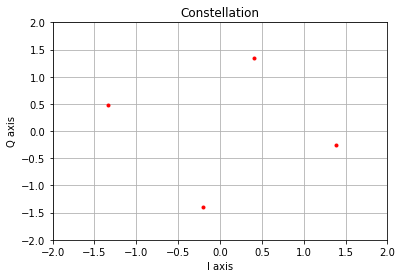

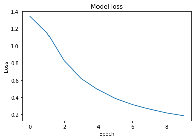

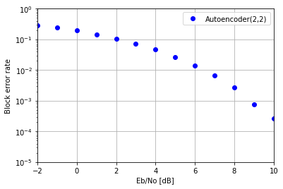

```python
testModel(k= 2, n=2)
```

```
 ********* Testing autoencoder architecture *********

M: 4 	 k: 2 	 n: 4

(4000, 4)
(400, 4)
Fixed energy constraint
Model: "model_84"
_________________________________________________________________
Layer (type)                 Output Shape              Param #
=================================================================
input_97 (InputLayer)        [(None, 4)]               0
_________________________________________________________________
dense_152 (Dense)            (None, 4)                 20
_________________________________________________________________
dense_153 (Dense)            (None, 4)                 20
_________________________________________________________________
lambda_47 (Lambda)           (None, 4)                 0
_________________________________________________________________
gaussian_noise_29 (GaussianN (None, 4)                 0
_________________________________________________________________
dense_154 (Dense)            (None, 4)                 20
_________________________________________________________________
dense_155 (Dense)            (None, 4)                 20
=================================================================
Total params: 80
Trainable params: 80
Non-trainable params: 0
_________________________________________________________________
Train on 4000 samples, validate on 400 samples
Eb/No: -2.0 BLER: 0.27534
Eb/No: -1.0 BLER: 0.22817
Eb/No: 0.0 BLER: 0.18225
Eb/No: 1.0 BLER: 0.13624
Eb/No: 2.0 BLER: 0.10008
Eb/No: 3.0 BLER: 0.06597
Eb/No: 4.0 BLER: 0.03964
Eb/No: 5.0 BLER: 0.02113
Eb/No: 6.0 BLER: 0.01062
Eb/No: 7.0 BLER: 0.0045
Eb/No: 8.0 BLER: 0.00152
Eb/No: 9.0 BLER: 0.00047
Eb/No: 10.0 BLER: 0.00011
```

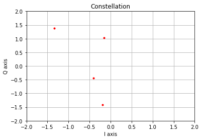

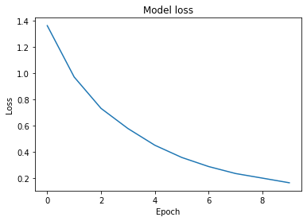

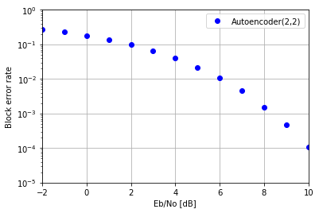

```python
testModel(k= 2, n=4)
```

```
 ********* Testing autoencoder architecture *********

M: 16 	 k: 4 	 n: 2

(16000, 16)
(1600, 16)
Fixed energy constraint
Model: "model_87"
_________________________________________________________________
Layer (type)                 Output Shape              Param #
=================================================================
input_99 (InputLayer)        [(None, 16)]              0
_________________________________________________________________
dense_156 (Dense)            (None, 16)                272
_________________________________________________________________
dense_157 (Dense)            (None, 2)                 34
_________________________________________________________________
lambda_48 (Lambda)           (None, 2)                 0
_________________________________________________________________
gaussian_noise_30 (GaussianN (None, 2)                 0
_________________________________________________________________
dense_158 (Dense)            (None, 16)                48
_________________________________________________________________
dense_159 (Dense)            (None, 16)                272
=================================================================
Total params: 626
Trainable params: 626
Non-trainable params: 0
_________________________________________________________________
Train on 16000 samples, validate on 1600 samples
Eb/No: -2.0 BLER: 0.65949
Eb/No: -1.0 BLER: 0.62591
Eb/No: 0.0 BLER: 0.5827
Eb/No: 1.0 BLER: 0.5395
Eb/No: 2.0 BLER: 0.48985
Eb/No: 3.0 BLER: 0.43816
Eb/No: 4.0 BLER: 0.38655
Eb/No: 5.0 BLER: 0.33425
Eb/No: 6.0 BLER: 0.27873
Eb/No: 7.0 BLER: 0.22448
Eb/No: 8.0 BLER: 0.17546
Eb/No: 9.0 BLER: 0.13081
Eb/No: 10.0 BLER: 0.09135
```

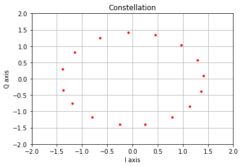

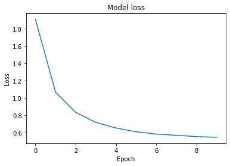

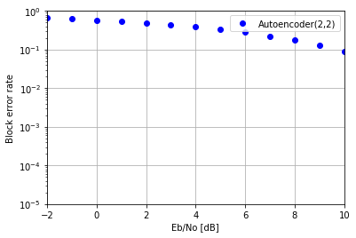

```python
testModel(k= 4, n=2)
```

### Comments

Increasing n with k staying the same, will decrease the error since we are using more dimension for coding, it is easier to differentiate each symbols. Increasing k with n staying the same, will create more symbols with same dimension for coding, it will increase the error.

The ranking: k= 4, n=2 k= 2, n=2 k= 2, n=4